# Competition: Pump it Up Data Mining the Water Table

by [María Luisa Duque](https://www.linkedin.com/in/marialuisaduque/)

2020-06-05

## INTRODUCCIÓN

El objetivo del presente trabajo es lograr la obtención de la mejor predicción para la competición [“Pump it Up Data Mining the Water Table”](https://www.drivendata.org/competitions/7/pump-it-up-data-mining-the-water-table/) de referencia; para ello, hemos explorado los datos, analizado, preparado, pre-procesado, seleccionado y hemos implementado los modelos **ranger()** y **xgboost()** para buscar aquél con el que se obtuviera un mejor score en la competición descrita.

El conjunto de datos original contiene 41 variables.

Los datasets a usar, proporcionados por la competición, son tres archivos .csv:

- 01_labels
- 02_trainset
- 03_testset

El objetivo es predecir qué pozos en la región de Tanzania serán funcionales, no funcionales o necesitarán reparación.

Los mejores resultados serán los obtenidos con el modelo **ranger()**, un score igual a **0,8265**.

El mejor score obtenido con el modelo **xgboost()** será igual a **0,8147**.

### Librerías y fijación del directorio de trabajo

```r
# Cargo las librerias
library(dataPreparation)
library(lubridate)
library(ranger)
library(data.table) # Para cargar y manipular
library(inspectdf)
library(dplyr)      # Para manipular
library(ggplot2)
library(ranger)
library(caret)
library(corrplot)
library (rpart)
library (rpart.plot)
library(DataExplorer)

# Fijo la semilla, 42 por buenas prácticas
set.seed(42)

# Fijo el directorio de trabajo
setwd('C:/Users/maria/Desktop/Temario Big Data/10 Machine Learning 2/dataset competition')
```

### Carga de datos

```r
# Labels
datLabel <- as.data.frame(fread("01_labels.csv", nThread = 4 ))
dim(datLabel)
```

```
## [1] 59400     2
```

```r
# Train
datTrain <- as.data.frame(fread("02_trainset.csv", nThread = 4 ))
dim(datTrain)
```

```
## [1] 59400    40
```

```r
# Test
datTest <- as.data.frame(fread('03_testset.csv', nThread = 4 ))
dim(datTest)
```

```
## [1] 14850    40
```

### Unión de Labels y Train

```r
all.equal(datLabel[,1], datTrain[,1])
```

```
## [1] TRUE
```

Tienen el mismo órden, aunque hago un merge.

```r
datEnd <- merge(datTrain, datLabel, by.x = "id", by.y="id", all = TRUE)

# Visualizamos el conjunto de datos datEnd
head(datEnd)
```

```
##   id amount_tsh date_recorded          funder gps_height installer longitude
## 1  0          0    2012-11-13           Tasaf          0     TASAF  33.12583
## 2  1          0    2011-03-05           Shipo       1978     SHIPO  34.77072
## 3  2          0    2011-03-27            Lvia          0      LVIA  36.11506
## 4  3         10    2013-06-03 Germany Republi       1639       CES  37.14743
## 5  4          0    2011-03-22            Cmsr          0      CMSR  36.16489
## 6  5         50    2011-02-26         Private         28   Private  39.28612
##    latitude       wpt_name num_private           basin subvillage      region
## 1 -5.118154        Mratibu           0 Lake Tanganyika    Majengo      Tabora
## 2 -9.395642           none           0          Rufiji   Magoda C      Iringa
## 3 -6.279268        Bombani           0     Wami / Ruvu Songambele      Dodoma
## 4 -3.187555 Area 7 Namba 5           0         Pangani    Urereni Kilimanjaro
## 5 -6.099289        Ezeleda           0     Wami / Ruvu    Maata A      Dodoma
## 6 -6.972403      Kwa Namaj           0     Wami / Ruvu   Mwandege       Pwani
##   region_code district_code      lga             ward population public_meeting
```

[output cut: 48 more lines]

```r
colnames(datEnd)
```

```
##  [1] "id"                    "amount_tsh"            "date_recorded"
##  [4] "funder"                "gps_height"            "installer"
##  [7] "longitude"             "latitude"              "wpt_name"
## [10] "num_private"           "basin"                 "subvillage"
## [13] "region"                "region_code"           "district_code"
## [16] "lga"                   "ward"                  "population"
## [19] "public_meeting"        "recorded_by"           "scheme_management"
## [22] "scheme_name"           "permit"                "construction_year"
## [25] "extraction_type"       "extraction_type_group" "extraction_type_class"
## [28] "management"            "management_group"      "payment"
## [31] "payment_type"          "water_quality"         "quality_group"
## [34] "quantity"              "quantity_group"        "source"
## [37] "source_type"           "source_class"          "waterpoint_type"
## [40] "waterpoint_type_group" "status_group"
```

## EDA: EXPLORATORY DATA ANALYSIS

Antes de hacer un trabajo de pre-procesado de los datos, consideramos conveniente realizar un Exploratory Data Analysis de los mismos para tener un poco más de información acerca de los datos y variables con las que estamos tratando; en definitiva, para conocer mejor los datos con los que estamos tratando.

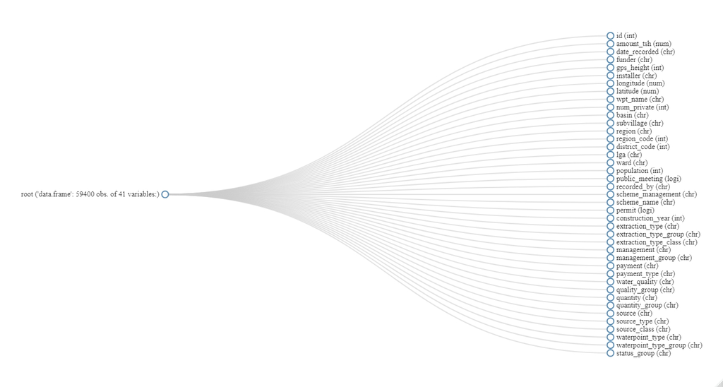

plot_str(datEnd)

```r
# Visualización de la estructura de nuestros datos
plot_str(datEnd)
```

Como podemos observar, en nuestro dataset datEnd disponemos de 41 variables y 59400 observaciones, así como visualizar el tipo de datos que tenemos por cada variable.

```r
# Filas, columnas, observaciones, missings
introduce(datEnd)
```

```
##    rows columns discrete_columns continuous_columns all_missing_columns
## 1 59400      41               31                 10                   0
##   total_missing_values complete_rows total_observations memory_usage
## 1                 6390         53281            2435400     21654280
```

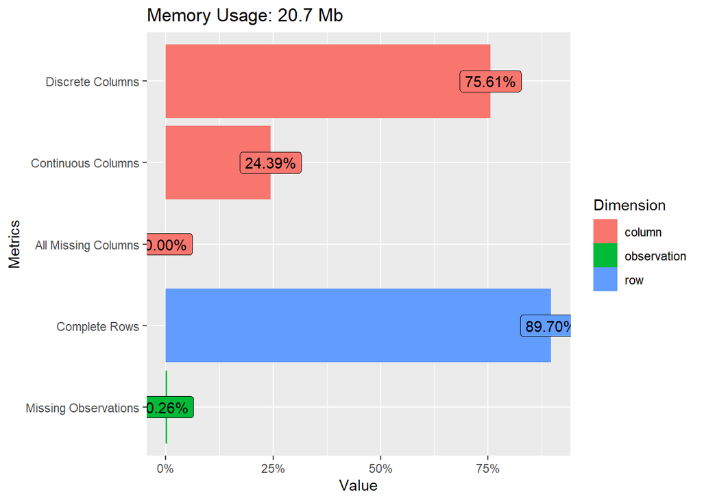

```r
plot_intro(datEnd)
```

Tenemos columnas continuas y discretas y además un total, indica, de 0.26% de observacionse missings.

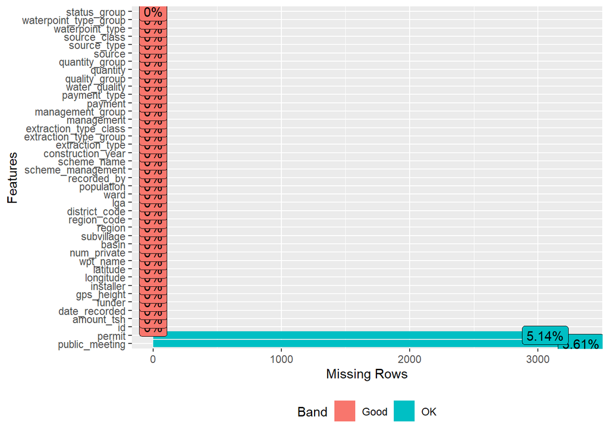

```r
# Valores missings por variable
plot_missing(datEnd)
```

```r
profile_missing(datEnd)
```

```
##                  feature num_missing pct_missing
## 1                     id           0  0.00000000
## 2             amount_tsh           0  0.00000000
## 3          date_recorded           0  0.00000000
## 4                 funder           0  0.00000000
## 5             gps_height           0  0.00000000
## 6              installer           0  0.00000000
## 7              longitude           0  0.00000000
## 8               latitude           0  0.00000000
## 9               wpt_name           0  0.00000000
## 10           num_private           0  0.00000000
## 11                 basin           0  0.00000000
## 12            subvillage           0  0.00000000
## 13                region           0  0.00000000
## 14           region_code           0  0.00000000
```

[output cut: 27 more lines]

Los valores missings se concentran en dos variables: permit y public_meeting. Posteriormente habrá que tratarlas en el preprocesado.

```
## 8 columns ignored with more than 50 categories.
## date_recorded: 356 categories
## funder: 1898 categories
## installer: 2146 categories
## wpt_name: 37400 categories
## subvillage: 19288 categories
## lga: 125 categories
## ward: 2092 categories
## scheme_name: 2697 categories
```

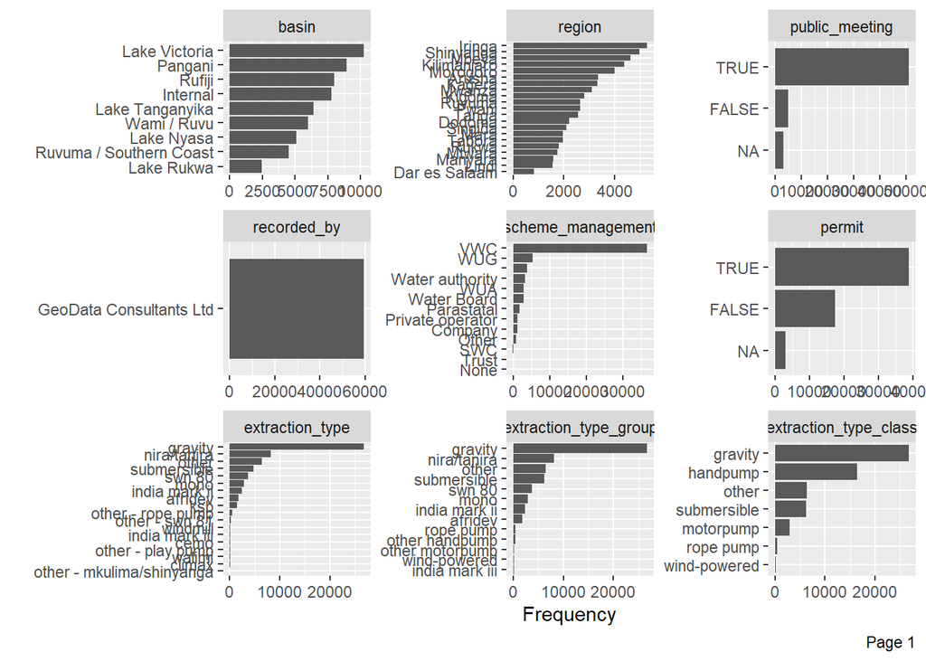

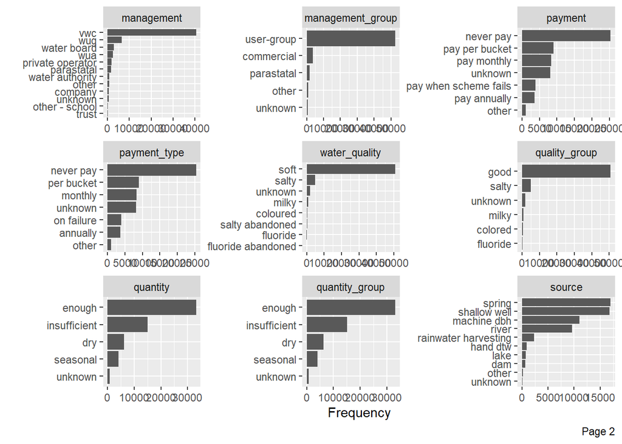

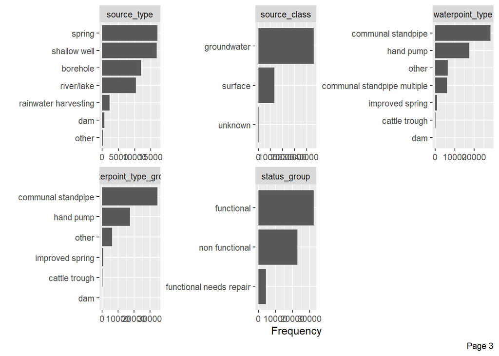

```r
# Bar charts: visualización de las distribuciones de frecuencias para las variables discretas
plot_bar(datEnd)
```

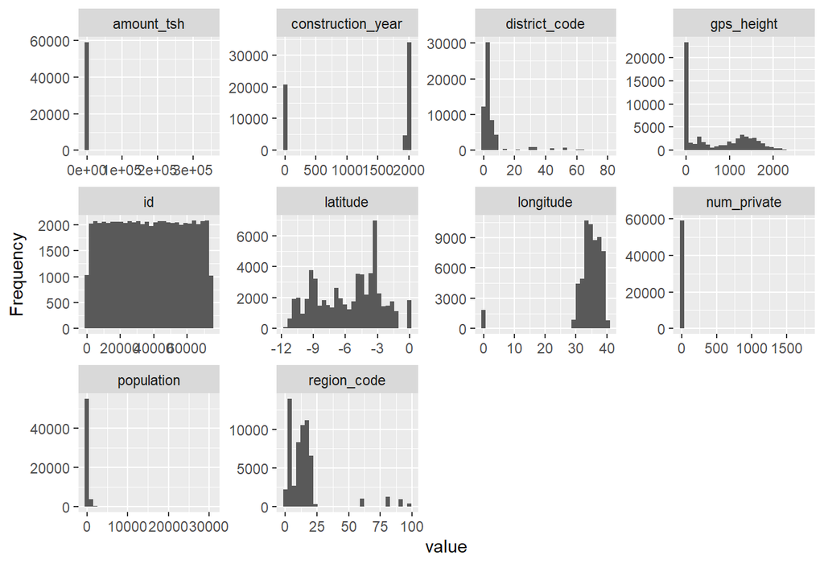

```r
# Histogramas: visualización de las distribuciones para las variables continuas
plot_histogram(datEnd)
```

Hay algunas cosas que podemos percibir, hay observaciones de latitude y longitude igual a 0, hecho que no resulta real puesto que los datos son del país Tanzania y este país está sobre el nivel del mar. La variable recorded_by sólo presenta un valor, no aporta información alguna, podría ser eliminada o no tomada en cuenta para nuestro modelo.

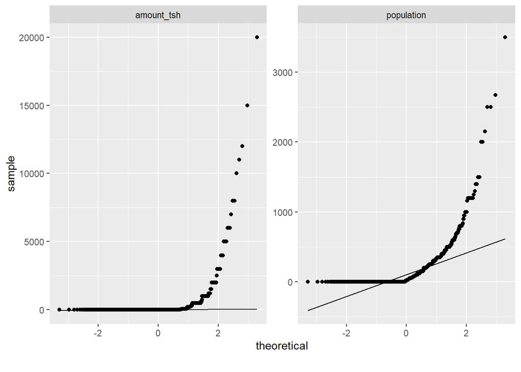

```r
# QQPlot
qq_data <- datEnd[, c("amount_tsh", "population")]
plot_qq(qq_data, sampled_rows = 1000L)
```

Quantile-Quantile plot es un modo para visualizar la desviación desde una específica probabilidad de distribución. Suele ser beneficioso para aplicar transformaciones tales como logaritmo sobre alguna de nuestras variables. Aquí, podrías considerar algunas transformación sobre amount_tsh y quizá sobre population, lo sopesaremos más adelante.

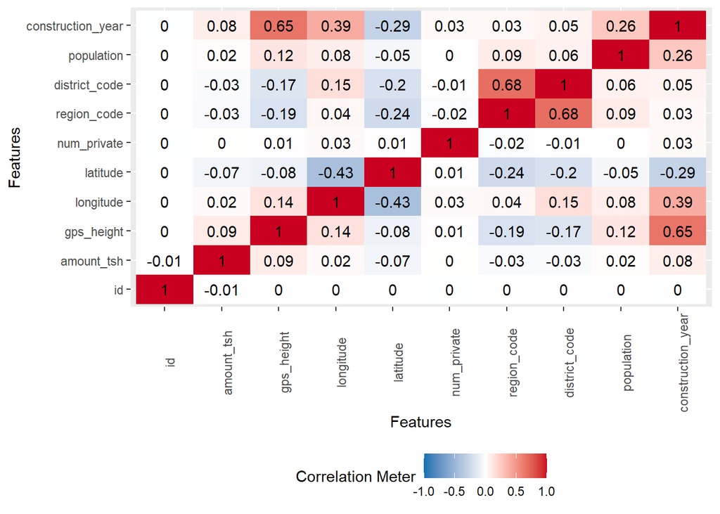

```r
# Análisis de correlación: mapa de calor para las variables continuas
plot_correlation(na.omit(datEnd), type = "c")
```

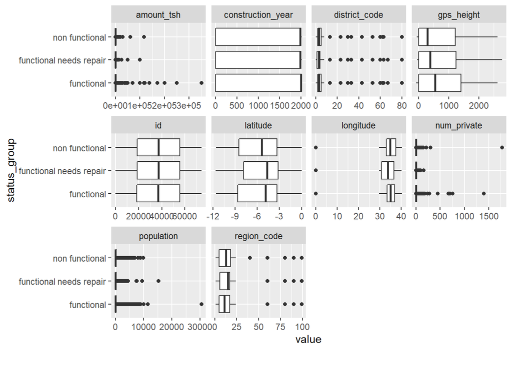

```r
# Boxplots: Visualización de las distribuciones de las variables continuas
plot_boxplot(datEnd, by = "status_group")
```

## FEATURE ENGINEERING Y PREPROCESADO

Feature engineering es el proceso de creación de nuevas variables desde variables existentes. Las nuevas variables creadas, generalmente aportan nueva información valiosa. También llevaremos a cabo un preprocesado. El objetivo es conseguir el tratamiento de los datos más óptimo.

### Transformación de variables a Factor

Analizando el dataset, compruebo que determinadas variables pueden ser pasadas a factor para garantizar un mejor funcionamiento de/los modelos posteriormente.

Estas variables son: waterpoint_type_group, basin, region, scheme_management, extraction_type, extraction_type_group, extraction_type_class, management, management_group, payment, payment_type, water_quality, quality_group, quantity, quantity_group, source, source_type, source_class, waterpoint_type, status_group, permit y public_meeting.

```r
datEnd2 = datEnd
datEnd2[,c(11, 13, 19, 21, 23, 25:41)] = lapply(datEnd2[,c(11, 13, 19, 21, 23, 25:41)], factor) # Train
datTest[,c(11, 13, 19, 21, 23, 25:40)] = lapply(datTest[,c(11, 13, 19, 21, 23, 25:40)], factor) # Test
```

### Creación de variables dummies

```r
datEnd2$permit
datEnd2$public_meeting
datEnd2$management_group
```

Vamos a imputar los valores missings NA’s, para ello definiremos previamente una función que nos permita hacerlo de forma eficiente y rápida. Imputaremos todos los valores missings de las variables tipo factor.

```r
# Definimos una función para la imputación variables cualitativas
ImputacionCuali<-function(vv,tipo){#tipo debe tomar los valores moda o aleatorio
  if (tipo=="moda"){
    vv[is.na(vv)]<-names(sort(table(vv),decreasing = T))[1]
  } else if (tipo=="aleatorio"){
    vv[is.na(vv)]<-sample(vv[!is.na(vv)],sum(is.na(vv)),replace = T)
  }
  factor(vv)
}

# Imputo los valores missing NA's con método aleatorio antes de crear las variables dummies
datEnd2[,as.vector(which(sapply(datEnd2, class)=="factor"))]<-sapply(Filter(is.factor, datEnd2),function(x) ImputacionCuali(x,"aleatorio"))

datTest[,as.vector(which(sapply(datTest, class)=="factor"))]<-sapply(Filter(is.factor, datTest),function(x) ImputacionCuali(x,"aleatorio"))

any(is.na(datEnd2$permit)) # Ya no tenemos NA's en permit
```

```
## [1] FALSE
```

```r
any(is.na(datEnd2$public_meeting)) # Ya no tenemos NA's tampoco en public_meeting
```

```
## [1] FALSE
```

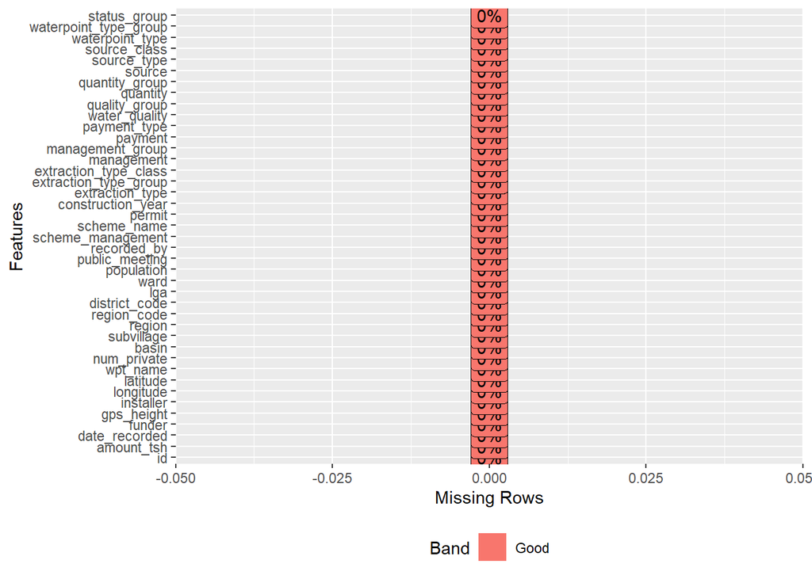

```r
# Lo podemos graficar haciendo uso de DataExplorer
no_missings <- set_missing(datEnd2, list(0L, "unknown"))
plot_missing(no_missings)
```

Para realizar la creación de variables dummies vamos a hacer uso de la librería *fastDummies()*.

```r
library(fastDummies)

# Creamos las dummies para permit, public_meeting y management_group tanto en Train como en Test
datEnd2 = dummy_cols(datEnd2,  select_columns = c("permit", "public_meeting", "management_group")) # Train
datTest = dummy_cols(datTest,  select_columns = c("permit", "public_meeting", "management_group")) # Test
```

### Creacion de variables adicionales

**FUNDER (El fundador del pozo)**

Extraemos la primera letra de la variable funder ya que mejora el modelo. La extraemos y la consideramos como factor tanto en train como en test.

```r
datEnd2$funder_2 = as.factor(substr(datEnd$funder, 1, 1)) # Train
datTest$funder_2 = as.factor(substr(datTest$funder, 1, 1)) # Test
```

**VOLUMEN (Cantidad de agua disponible en cada pozo)**

Creamos una variable del logaritmo de la variable amount_tsh. Escalamos la variable en el punto óptimo (que es 3.61). Transformamos la variable a logaritmica y luego hacemos dos tramos para convertirla en binaria.

```r
# Train
datEnd2$volumen_log = log(datEnd2$amount_tsh + 1)
datEnd2$volumen_2 = datEnd2$volumen_log * datEnd2$volumen_log
datEnd2$volumen_bin = 0
datEnd2$volumen_bin[datEnd2$volumen_log>3.61]=1

# Test
datTest$volumen_log = log(datTest$amount_tsh + 1)
datTest$volumen_2 = datTest$volumen_log * datTest$volumen_log
datTest$volumen_bin = 0
datTest$volumen_bin[datTest$volumen_log>3.61]=1
```

**DATE_RECORDED (Fecha de registro del pozo)**

Vamos a crear tres variables de antigüedad de los pozos registrados. Los días, los meses y los años. Para ello, tomamos de referencia la última fecha en la que se registro un pozo: 2014-01-01.

```r
# Train
datEnd2$dif_days <- as.numeric(as.Date("2014-01-01") - as.Date(datEnd2$date_recorded))
datEnd2$reg_month <- month(ymd(datEnd2$date_recorded))
datEnd2$reg_year <- year(ymd(datEnd2$date_recorded))

# Test
datTest$dif_days <- as.numeric(as.Date("2014-01-01") - as.Date(datTest$date_recorded))
datTest$reg_month <- month(ymd(datTest$date_recorded))
datTest$reg_year <- year(ymd(datTest$date_recorded))
```

**LOCALIZACIÓN DE CADA POZO**

Usando las variables longitude y latitude podemos crear una variable con la localización/posición de cada pozo. Para ello, haremos uso de la función *distGeo()* del paquete *geosphere*.

```r
library(geosphere)

# Train
datEnd2$dist_geo <- distGeo(as.matrix(datEnd2[,c('longitude','latitude')]), c(0,0))

# Test
datTest$dist_geo <- distGeo(as.matrix(datTest[,c('longitude','latitude')]), c(0,0))
```

### Transformación de variables

**LONGITUDE**

```r
# Train
longsummary <- aggregate(longitude~region,data=datEnd2[(datEnd2$longitude!=0),], FUN=mean)
datEnd2$longitud_ok = datEnd2$longitud
nrow(datEnd2[datEnd2$longitud_ok==0,])
```

```
## [1] 1812
```

```r
listado_regiones = levels(datEnd2$region)
for (r in listado_regiones){
  datEnd2$longitud_ok[datEnd2$region== r & datEnd2$longitude==0] <- longsummary$longitude[longsummary== r]}

# Test
datTest$longitud_ok = datTest$longitud
nrow(datTest[datTest$longitud_ok==0,])
```

```
## [1] 457
```

```r
listado_regiones_test = levels(datTest$region)
for (r in listado_regiones_test){
  datTest$longitud_ok[datTest$region== r & datTest$longitude==0] <- longsummary$longitude[longsummary== r]}
```

**POPULATION**

Escalamos la variable población para evitar posibles problemas de falta de distribución uniforme entre train y test.

```r
datEnd2$population_sc = scale(datEnd2$population) # Train
datTest$population_sc = scale(datTest$population) # Test
```

### Agrupación de variables con árboles

Vamos a generar agrupaciones de las variables scheme_management y region porque dan mejores resultados estás variables de tal modo. Optaremos por la agrupación mediante árboles de decisión haciendo uso de la función rpart(). Estos arboles clasificarán cada una de las variables independientes escogidas, en este caso dos, conforme a la dependiente status_group mediante un árbol de decisión, cuyas clasificaciones generadas obtendremos y agruparemos así nuestro par de variables.

```r
# Region
tree<-rpart(status_group~region, data=datEnd2)
da<-cbind(var=datEnd2$region,tree=tree$where,obj=datEnd2$status_group)
datEnd2$region_agrup<-factor(tree$where)
levels(datEnd2$region_agrup)
```

```
## [1] "2" "3"
```

```r
tabla.agrupada = datEnd2 %>% dplyr::group_by(region_agrup, region) %>% dplyr::summarize(total = n())
agrupador1 <- merge(datTest, tabla.agrupada, by.x = "region", by.y="region", all.x =TRUE)
agrupador1 = agrupador1 <- subset(agrupador1, select = c(id, region_agrup))
datTest <- merge(datTest, agrupador1, by.x = "id", by.y="id", all.x =TRUE, sort= FALSE)
datTest[,as.vector(which(sapply(datTest, class)=="factor"))]<-sapply(Filter(is.factor, datTest),function(x) ImputacionCuali(x,"aleatorio"))
datTest$region_agrup = as.factor(datTest$region_agrup)

# scheme_management
tree<-rpart(status_group~scheme_management, data=datEnd2)
da<-cbind(var=datEnd2$scheme_management,tree=tree$where,obj=datEnd2$status_group)
datEnd2$scheme_management_agrup<-factor(tree$where)
levels(datEnd2$scheme_management_agrup)
```

```
## [1] "1"
```

```r
tabla.agrupada = datEnd2 %>% dplyr::group_by(scheme_management_agrup, scheme_management) %>% dplyr::summarize(total = n())
agrupador1 <- merge(datTest, tabla.agrupada, by.x = "scheme_management", by.y="scheme_management", all.x =TRUE)
agrupador1 = agrupador1 <- subset(agrupador1, select = c(id, scheme_management_agrup))
datTest <- merge(datTest, agrupador1, by.x = "id", by.y="id", all.x =TRUE, sort= FALSE)
```